# Assignment 1: Analyzing an Obesity dataset

William Schaafsma, Qingyu Meng, Hau Nguyen, Bénine Karssen

26-05-2022

# 1 Introduction And Research Question

In this assignment an obesity dataset, retrieved from [Palechor & Manotas, 2019](https://www-sciencedirect-com.proxy.library.uu.nl/science/article/pii/S2352340919306985?via%3Dihub) will be analyzed. The data gathered for this paper comes from individuals that live in Peru, Mexico and Colombia. It’s stated that 23% of the data is “real” and that 77% has been synthetically generated.

The goal for this assignment is to build a linear model that most accurately predicts the BMI of *new* patients, therefore we mainly focus on prediction. However, from the inference perspective, understanding which predictors have great influence for one’s BMI is favorable for policymakers regarding national health. Moreover, patients will get more understanding of their own health.

We will work in an exploratory manner. Thus, in this assignment we are particularly interested in: *‘What predictors show the greatest influence regarding a person’s BMI?’*

# 2 Loading Packages, Dataset & Set seed

## 2.1 Import the Packages

The following libraries are required to run this program successfully.

```r
library(ggplot2) # Data visualization
library(corrplot) # Correlation plot
library(MASS) # Use of stepAIC()
library(car) # Use of min-max function
library(dplyr) # Data manipulation
library(knitr) # Produce table & structure in RMarkdown style
library(tidyverse) # # Filtering unnecessary predictors
library(mice) # Checking for missing values
library(magrittr) # Pipes
library(readr) # Loading dataset
library(caret) # Model evaluation
library(leaps) # Best subset selection
library(glmnet) # Model building
library(psych) # # Use of describe() function and pairplot
library(fastDummies) # Dummy coding
library(stats) # Statistical computation
library(vcd) # Correlation calculation for categorical variables
library(olsrr) # Model building
library(MLmetrics) # Calculating MSE
```

## 2.2 Import The Dataset & Set Seed

First we load the data and set the seed in order to generate a reproducible result.

```r
# loading data
obese <- read_csv("ObesityDataSet_raw_and_data_sinthetic (2)/ObesityDataSet_raw_and_data_sinthetic.csv")

# set the seed
set.seed(2022)
```

# 3 Processing Of The Data

## 3.1 Preprocessing (Data Manipulation)

We want to include BMI as a dependent/response variable in our model, but we only have the ‘Weight’ and ‘Height’ columns in hand. To do this we need to derive BMI from Weight and Height with the formula: $BMI = Weight / Height^2$

Since we use BMI as the dependent variable, high multicollinearity problems will evolve in *Height* and *Weight* for example in building a model or evaluating their correlations. Therefore we will delete these predictors since they’ve become irrelevant after the introduction of the BMI variable. Besides, the ‘NObeyesdad’ column concerns body weight grouping, since we will not involve in a classification task in this project, this column is never in use and we can directly delete it.

```r
# calculating BMI from height and weight
Bmi <- data.frame(Bmi = (obese$Weight / (obese$Height^2)))

# adding BMI to the original dataframe
obese_mid <- cbind(obese, Bmi)

# removing *NObeyesdad* since we don't need the variable
obese_complete <- subset(obese_mid, select = -c(NObeyesdad, Height, Weight))
```

Our dataset contains several categorical variables (“Gender”, “family_history_with_overweight”, “FAVC”, “SMOKE”, “SCC”, “CALC”, “CAEC”, “MTRANS”), which needs to be dummy-coded later times in order to gain a meaningful interpretation after building the models.

First, we convert the categorical columns into factors, which includes “Gender”, “family_history_with_overweight”, “FAVC”, “SMOKE”, “SCC”, “CALC”, “CAEC”, “MTRANS”. Note that some of them are categorical variables but in numeric type.

```r
# converting mentioned columns into factor variables
obese_complete$Gender <- as.factor(obese_complete$Gender)

obese_complete$family_history_with_overweight <- as.factor(obese_complete$family_history_with_overweight)

obese_complete$FAVC <- as.factor(obese_complete$FAVC)
obese_complete$SMOKE<- as.factor(obese_complete$SMOKE)
obese_complete$SCC <- as.factor(obese_complete$SCC)
obese_complete$CALC <- as.factor(obese_complete$CALC)
obese_complete$CAEC <- as.factor(obese_complete$CAEC)
obese_complete$MTRANS <- as.factor(obese_complete$MTRANS)
```

To aid our interpretation for the dummy coefficients, we reassign the reference level for some columns.

```r
obese_complete$CALC <- relevel(obese_complete$CALC, ref = "no")
obese_complete$CAEC <- relevel(obese_complete$CAEC, ref = "no")
obese_complete$MTRANS <- relevel(obese_complete$MTRANS, ref = "Walking")
```

## 3.2 Splitting The Data Into Train, Validation & Test

In order to evaluate the performance of the model we will build later on, we have to split the data into three partitions: Train, Test, Validation. The data will be split in a way that ~70% of the data is used for training the model, ~20% for validating the model and ~10% for testing the model.

```r
# partition of training
part_train <- createDataPartition(obese_complete$Bmi, p = .7,
                                  list = FALSE,
                                  times = 1)

# creation of training data
obese_train <- obese_complete[part_train, ]

# remainder for validation and testing
part_test_val <- obese_complete[-part_train, ]

# partition of validation
part_val <- createDataPartition(part_test_val$Bmi, p = .66,
                                list = FALSE,
                                times = 1)
# creation of validation data
obese_val <- part_test_val[part_val, ]

# creation of test data
obese_test  <- part_test_val[-part_val, ]
```

To verify our dataset was normally distributed, we can make a corresponding histogram and density plot.

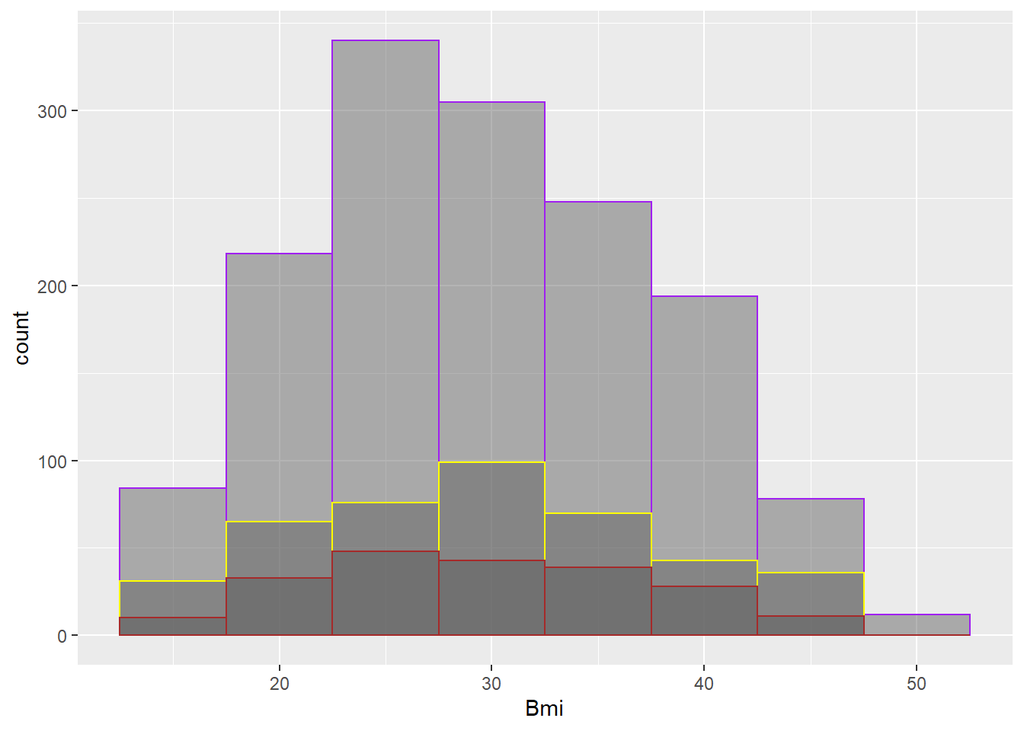

```r
# Histogram of the Bmi distribution in spliting datasets
ggplot() +
  geom_histogram(data = obese_train, mapping = aes(x = Bmi), alpha = 0.45, colour = "Purple", binwidth = 5) +
  geom_histogram(data = obese_val, mapping = aes(x = Bmi), alpha = 0.45, colour = "Yellow", binwidth = 5) +
  geom_histogram(data = obese_test, mapping = aes(x = Bmi), alpha = 0.45, colour = "Brown", binwidth = 5)
```

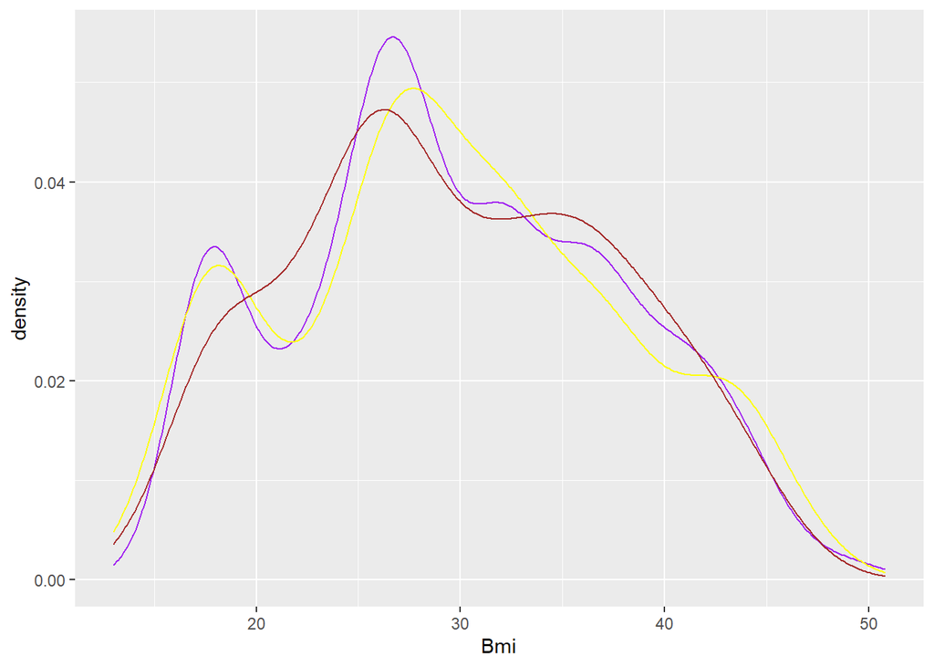

```r
# Histogram of the Bmi distribution in spliting datasets
ggplot() +
  geom_density(data = obese_train, mapping = aes(x = Bmi), alpha = 0.45, colour = "Purple") +
  geom_density(data = obese_val, mapping = aes(x = Bmi), alpha = 0.45, colour = "Yellow") +
  geom_density(data = obese_test, mapping = aes(x = Bmi), alpha = 0.45, colour = "Brown")
```

Each of the plots above are highly overlapping, suggesting that the obese_complete dataset was randomly and normally distributed into the training set, validation set and test set respectively.

## 3.3 Explaining The Variables

**WARNING:** the simulated data created incorrect data. Particularly, it treated categorical data as numeric data and therefore wrongfully imputed these data. However, in this assignment we will treat these data as if they were numeric since converting the datatypes causes loads of parsing errors. This problem affects the following variables: *FCVC, NCP, CH2O, FAF* and *TUE*.

Then the continuous variable **Height** that contains floating values for a person’s Height, measured in meters. Then there’s another continuous variable **Weight** that also contains floating values for a person’s weight, measured in Kilograms (KG).

There’s also the dichotomous variable **family_history_with_overweight** which controls for possible genetic predisposition for a high BMI. Next is another dichotomous variable **FAVC** that represents whether a person frequently consumes high caloric foods.

Then a “numeric” variable **FCVC** which represents the frequency of consuming vegetables. Then there’s another “numeric” variable **NCP** that accounts for the number of main meals each day.

Next is the categorical variable **CAEC** consisting of four categories representing the consumption of foods between meals: No, Sometimes, Frequently, Always. Then there is a dichotomous variable **SMOKE** that represents whether a person smokes

Next is a “numeric” variable **CH2O** which represents the amount of water a person drinks each day. Next is another dichotomous variable **SCC** that accounts for calorie checking.

Then there’s a “numeric” variable **FAF** which represents the frequency of physical activity of a person. Next is another “numeric” variable **TUE** which represents the amount a person spends on it’s devices such as a phone.

Then there is the categorical variable **CALC** consisting of four categories representing a person’s alcohol intake: Nothing, Sometimes, Frequently, Always. Finally, there is the categorical variable **MTRANS** consisting of five categories representing a person’s most used public transport: Automobile, Motorbike, Bike, Public Transportation and Walking.

## 3.4 Getting To Know The Data

In order to work with a dataset, we need to understand the dataset. First, let’s check whether there are missing data in our dataset. To do this we use the `mice` package.

```r
md.pattern(obese_complete, rotate.names = TRUE)
```

```
 /\     /\
{  `---'  }
{  O   O  }
==>  V <==  No need for mice. This data set is completely observed.
 \  \|/  /
  `-----'
```

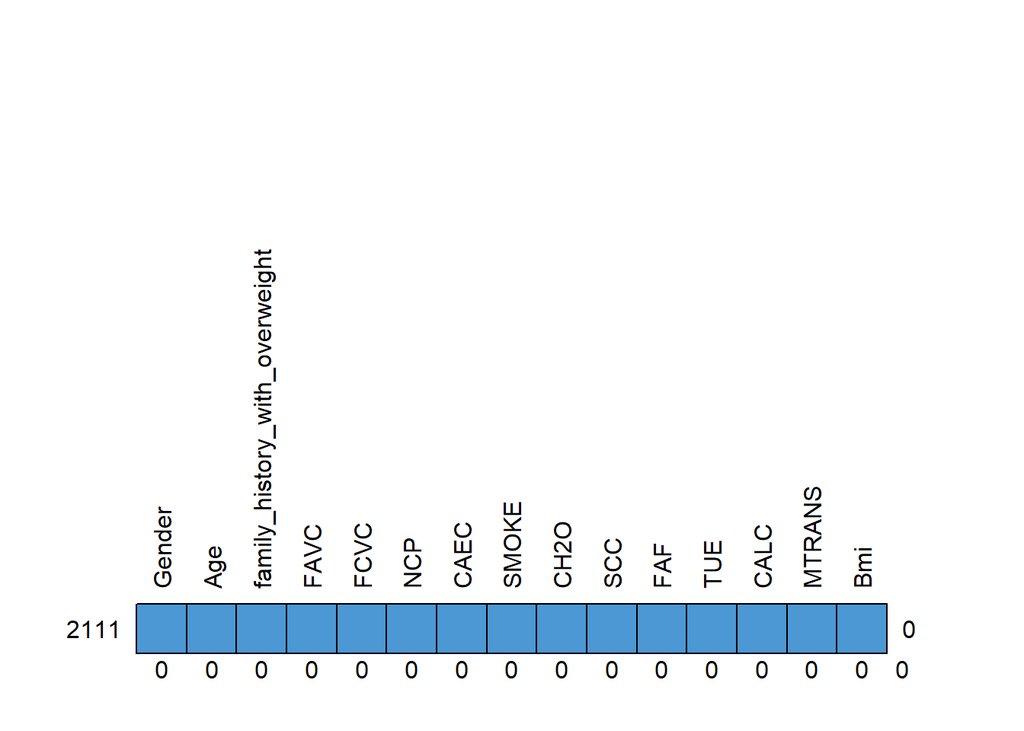

```
     Gender Age family_history_with_overweight FAVC FCVC NCP CAEC SMOKE CH2O
2111      1   1                              1    1    1   1    1     1    1
          0   0                              0    0    0   0    0     0    0
     SCC FAF TUE CALC MTRANS Bmi
2111   1   1   1    1      1   1 0
       0   0   0    0      0   0 0
```

Fortunately, we can conclude that our dataset contains no missing values. Furthermore, the figure shows that our dataset holds 15 variables and 2111 observations.

Now, let us see the head of the data.

```r
head(obese_complete) %>%
  knitr::kable(format = "markdown", digits= 1, padding = 30, align = 'c')
```

| Gender | Age | family_history_with_overweight | FAVC | FCVC | NCP | CAEC | SMOKE | CH2O | SCC | FAF | TUE | CALC | MTRANS | Bmi |
| --- | --- | --- | --- | --- | --- | --- | --- | --- | --- | --- | --- | --- | --- | --- |
| Female | 21 | yes | no | 2 | 3 | Sometimes | no | 2 | no | 0 | 1 | no | Public_Transportation | 24.4 |
| Female | 21 | yes | no | 3 | 3 | Sometimes | yes | 3 | yes | 3 | 0 | Sometimes | Public_Transportation | 24.2 |
| Male | 23 | yes | no | 2 | 3 | Sometimes | no | 2 | no | 2 | 1 | Frequently | Public_Transportation | 23.8 |
| Male | 27 | no | no | 3 | 3 | Sometimes | no | 2 | no | 2 | 0 | Frequently | Walking | 26.9 |
| Male | 22 | no | no | 2 | 1 | Sometimes | no | 2 | no | 0 | 0 | Sometimes | Public_Transportation | 28.3 |
| Male | 29 | no | yes | 2 | 3 | Sometimes | no | 2 | no | 0 | 0 | Sometimes | Automobile | 20.2 |

From the head and describe function we can tell that the data has loaded as expected and that the datatypes are in line with how we described them in section “Explaining the variables”.

Let’s also check the describe function.

```r
describe(obese_complete)
```

```
                                vars    n  mean   sd median trimmed  mad min
Gender*                            1 2111  1.51 0.50   2.00    1.51 0.00   1
Age                                2 2111 24.31 6.35  22.78   23.34 4.78  14
family_history_with_overweight*    3 2111  1.82 0.39   2.00    1.90 0.00   1
FAVC*                              4 2111  1.88 0.32   2.00    1.98 0.00   1
FCVC                               5 2111  2.42 0.53   2.39    2.46 0.57   1
NCP                                6 2111  2.69 0.78   3.00    2.77 0.00   1
CAEC*                              7 2111  3.76 0.61   4.00    3.92 0.00   1
SMOKE*                             8 2111  1.02 0.14   1.00    1.00 0.00   1
CH2O                               9 2111  2.01 0.61   2.00    2.01 0.67   1
SCC*                              10 2111  1.05 0.21   1.00    1.00 0.00   1
FAF                               11 2111  1.01 0.85   1.00    0.94 1.19   0
TUE                               12 2111  0.66 0.61   0.63    0.59 0.72   0
CALC*                             13 2111  3.06 1.37   4.00    3.20 0.00   1
MTRANS*                           14 2111  4.23 1.34   5.00    4.45 0.00   1
Bmi                               15 2111 29.70 8.01  28.72   29.52 9.07  13
                                  max range  skew kurtosis   se
Gender*                          2.00  1.00 -0.02    -2.00 0.01
Age                             61.00 47.00  1.53     2.81 0.14
family_history_with_overweight*  2.00  1.00 -1.64     0.70 0.01
FAVC*                            2.00  1.00 -2.40     3.74 0.01
FCVC                             3.00  2.00 -0.43    -0.64 0.01
NCP                              4.00  3.00 -1.11     0.38 0.02
CAEC*                            4.00  3.00 -2.97     8.94 0.01
SMOKE*                           2.00  1.00  6.70    42.95 0.00
CH2O                             3.00  2.00 -0.10    -0.88 0.01
SCC*                             2.00  1.00  4.36    17.02 0.00
FAF                              3.00  3.00  0.50    -0.62 0.02
TUE                              2.00  2.00  0.62    -0.55 0.01
CALC*                            4.00  3.00 -0.81    -1.30 0.03
MTRANS*                          5.00  4.00 -1.23    -0.37 0.03
Bmi                             50.81 37.81  0.15    -0.81 0.17
```

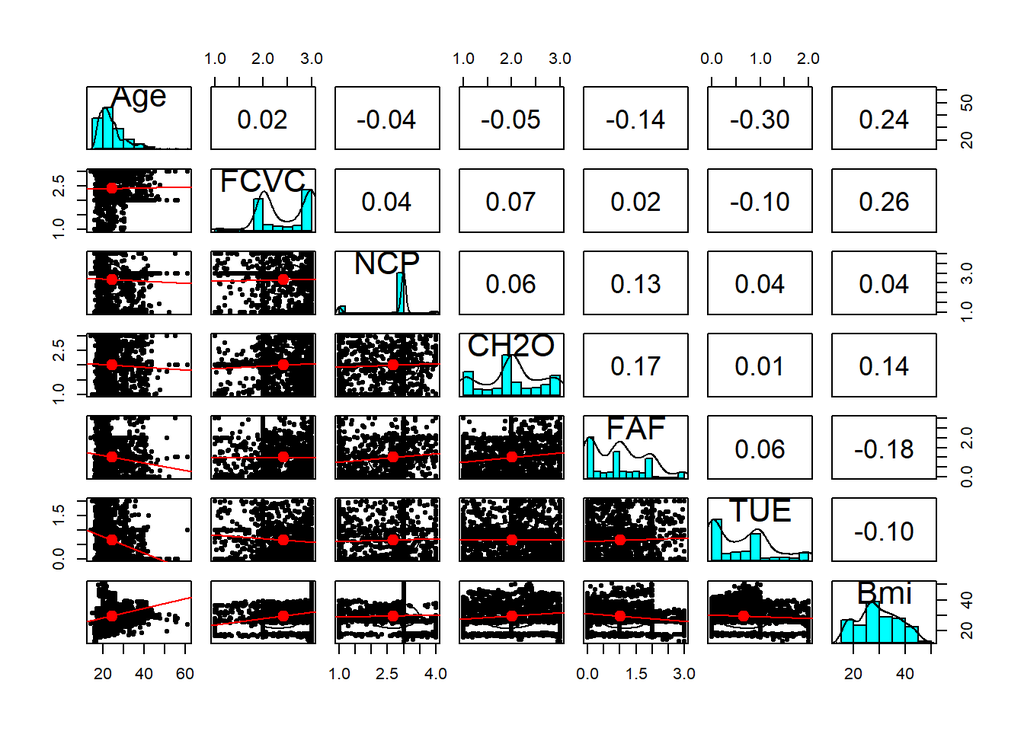

```r
continuous_variables <- select(obese_complete, -c("Gender", "family_history_with_overweight", "FAVC", "SMOKE", "SCC", "CALC", "CAEC", "MTRANS"))
# Distribution of numeric variables and correlation between them
pairs.panels(continuous_variables, density = TRUE, ellipses = TRUE, smooth = FALSE, lm = TRUE)
```

Also the correlation plot shows the distribution of the numeric variables and the relationships between the variables. Right now, when looking at the within relationships of the numeric variables, we should not have to worry about the presence of multicollinearity in the subset of numeric data.

# 4 Exploratory Data Analysis

## 4.1 Bivariate Analysis

Suppose we want to look for a difference in the average Bmi of a person based on the CAEC variable. We are thus looking for a relationship between a continuous and (nominal/ordinal) categorical variable. Therefore, we should make a boxplot to look for this relationship graphically. Same ideas applies for other pairs of such relationships, in which we should also make boxplots to look into the data. Considering the limitation of lengths for this section, we will only explore the following variables pairs: CAEC ~ Bmi, Gender ~ Bmi and MTRANS ~ Bmi.

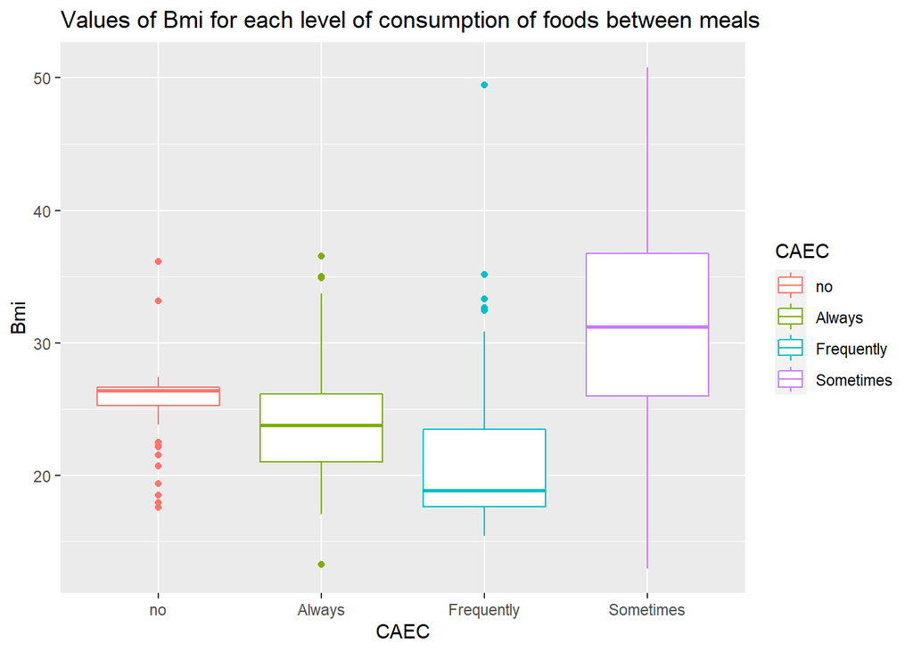

```r
# Visualizations of individual variables -- CAEC
ggplot(obese_complete, aes(x = CAEC, y = Bmi, color = CAEC)) +
  geom_boxplot() +
  labs(title = "Values of Bmi for each level of consumption of foods between meals")
```

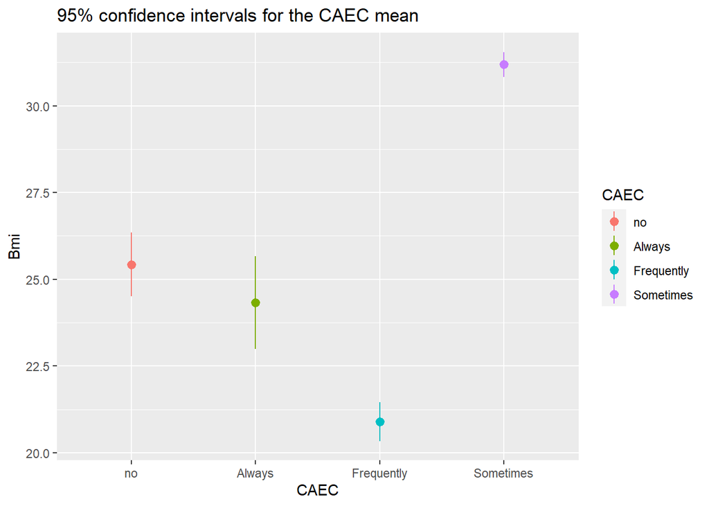

```r
# 95% confidence intervals for the CAEC mean
ci_CAEC <- \(x) mean_se(x, mult = 1.96)
ggplot(obese_complete, aes(CAEC, Bmi, color = CAEC)) +
  stat_summary(fun.data = ci_CAEC) +
  labs(title = "95% confidence intervals for the CAEC mean")
```

Next, we draw the graph for the case when “Gender” is the explanatory variable.

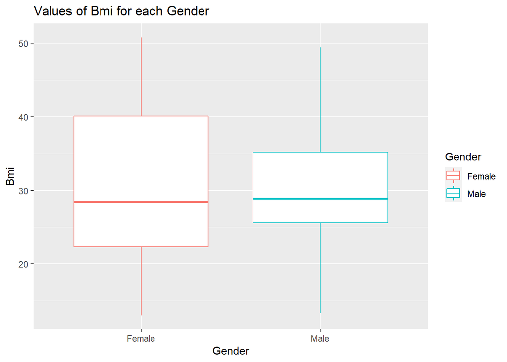

```r
# Visualizations of individual variables -- Gender
ggplot(obese_complete, aes(x = Gender, y = Bmi, color = Gender)) +
  geom_boxplot() +
  labs(title = "Values of Bmi for each Gender")
```

```r
table(obese_complete$Gender)
```

```
Female   Male
  1043   1068
```

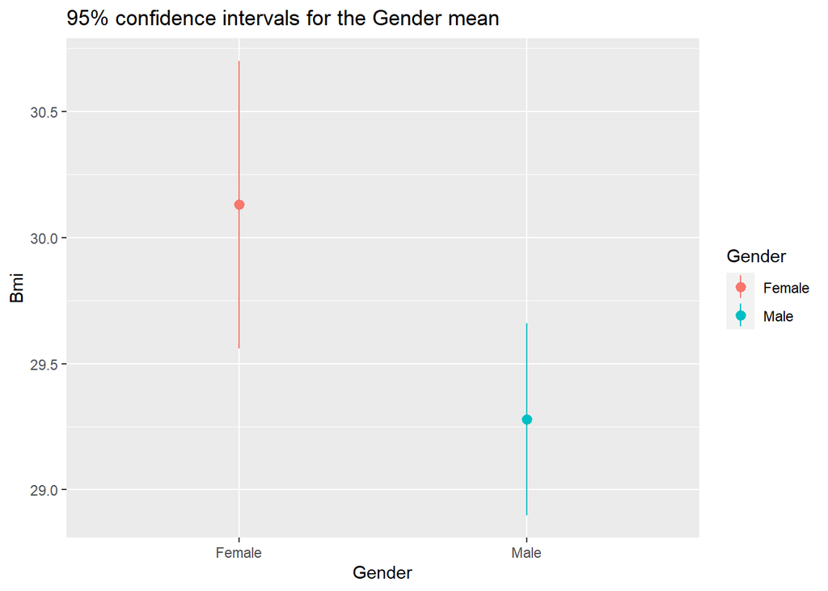

```r
# 95% confidence intervals for the Gender mean
ci_gender <- \(x) mean_se(x, mult = 1.96)
ggplot(obese_complete, aes(Gender, Bmi, color = Gender)) +
  stat_summary(fun.data = ci_gender) +
  labs(title = "95% confidence intervals for the Gender mean")
```

Then, let’s look at how does the different level for “MTRANS” variables affects average Bmi.

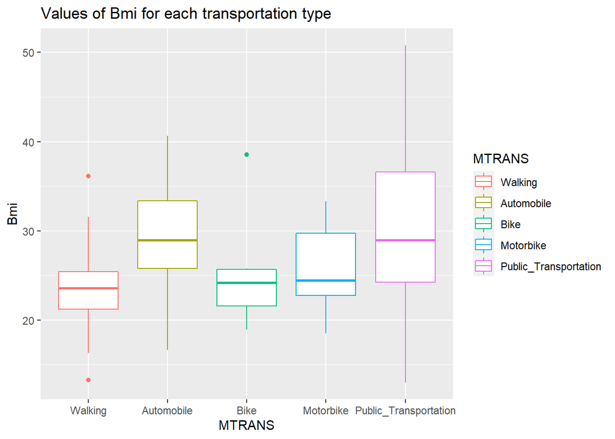

```r
# Visualizations of individual variables -- MTRANS
ggplot(obese_complete, aes(x = MTRANS, y = Bmi, color = MTRANS)) +
  geom_boxplot() +
  labs(title = "Values of Bmi for each transportation type")
```

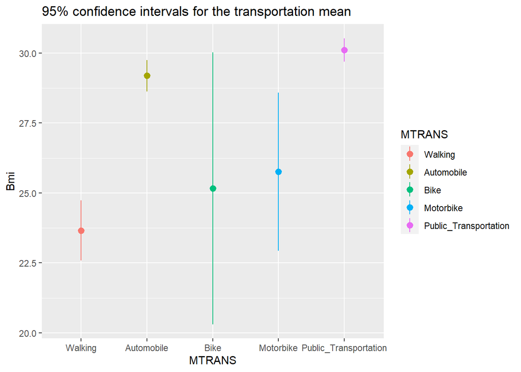

```r
# 95% confidence intervals for the MTRANS mean
ci_mtrans <- \(x) mean_se(x, mult = 1.96)
ggplot(obese_complete, aes(MTRANS, Bmi, color = MTRANS)) +
  stat_summary(fun.data = ci_mtrans) +
  labs(title = "95% confidence intervals for the transportation mean")
```

As did for the “Gender ~ Bmi” pair, here we check the distribution of the column “MTRANS” again.

```r
table(obese_complete$MTRANS)
```

```
              Walking            Automobile                  Bike
                   56                   457                     7
            Motorbike Public_Transportation
                   11                  1580
```

From the table we can say the shape for the “MTRANS” variable is highly biased, with majority of data being the type “Public_Transportation”, and very few data with the type “Bike”.

## 4.2 Correlations

In this section we will try to look for strong correlations between the predicting variables and our dependent variable BMI. The aim is to see how the variables seem to interact with each other, as well as to find the correlations between them.

We know that if all concerned variables are continuous numerical, we can use Pearson Correlation Coefficient to compute correlations between each pair of them. However, since in our dataset the categorical variables are all nominal (or partially ordinal), we should instead consider another correlation metrics: Cramer’s V. This is used to calculate the correlation between nominal categorical variables.

```r
continuous_variables <- select(obese_complete, -c("Gender", "family_history_with_overweight", "FAVC", "SMOKE", "SCC", "CALC", "CAEC", "MTRANS"))
categorical_variables <- select(obese_complete, c("Gender", "family_history_with_overweight", "FAVC", "SMOKE", "SCC", "CALC", "CAEC", "MTRANS"))
```

```r
cat_vars = c("Gender", "family_history_with_overweight", "FAVC", "SMOKE", "SCC", "CALC", "CAEC", "MTRANS")
cat_df = data.frame(categorical_variables)

catcorrm <- function(vars, dat) sapply(vars, function(y) sapply(vars, function(x) assocstats(table(dat[,x], dat[,y]))$cramer))
catcorrm(cat_vars, cat_df)
```

```
                                   Gender family_history_with_overweight
Gender                         1.00000000                     0.10251213
family_history_with_overweight 0.10251213                     1.00000000
FAVC                           0.06493377                     0.20803551
SMOKE                          0.04469809                     0.01738550
SCC                            0.10263348                     0.18542171
CALC                           0.05021680                     0.03957316
CAEC                           0.13607214                     0.35119369
MTRANS                         0.16750005                     0.12573500
                                     FAVC      SMOKE        SCC       CALC
Gender                         0.06493377 0.04469809 0.10263348 0.05021680
family_history_with_overweight 0.20803551 0.01738550 0.18542171 0.03957316
FAVC                           1.00000000 0.05065996 0.19065831 0.14171280
SMOKE                          0.05065996 1.00000000 0.04773123 0.11040783
SCC                            0.19065831 0.04773123 1.00000000 0.06705155
CALC                           0.14171280 0.11040783 0.06705155 1.00000000
CAEC                           0.19677903 0.05930085 0.16408493 0.10461431
MTRANS                         0.20520598 0.04299109 0.08220762 0.10461223
                                     CAEC     MTRANS
Gender                         0.13607214 0.16750005
family_history_with_overweight 0.35119369 0.12573500
FAVC                           0.19677903 0.20520598
SMOKE                          0.05930085 0.04299109
SCC                            0.16408493 0.08220762
CALC                           0.10461431 0.10461223
CAEC                           1.00000000 0.10459497
MTRANS                         0.10459497 1.00000000
```

The result produced by catcorrm() function is a correlation matrix of Cramer’s V’s. From this matrix we can see several pairs of categorical variables has relatively high correlations, such as ‘Gender ~ MTRANS’, ‘family_history_with_overweight ~ FAVC/SCC/CAEC’, ‘FAVC ~ SCC’, ‘FAVC ~ MTRANS’, ‘SCC ~ CAEC’ and ‘CAEC ~ FAVC’.

For numeric variables in the dataset, we can use corrplot() function to visualize their correlations.

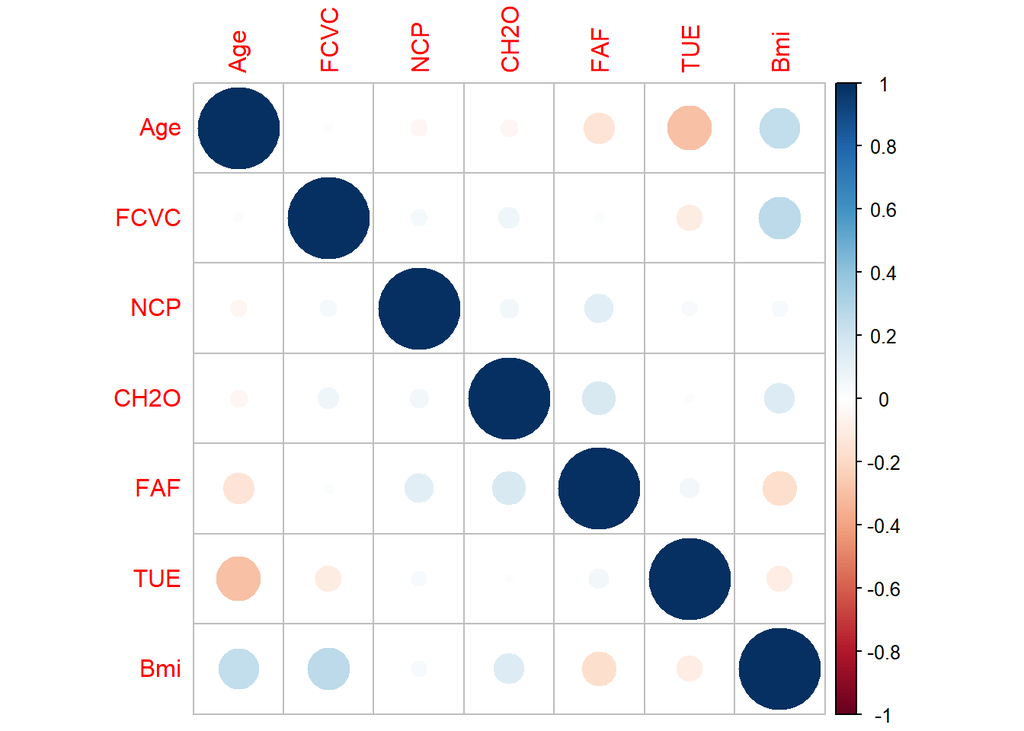

```r
corrplot(cor(continuous_variables),
         method = "circle",
         type = "full",
         tl.pos = "tl",
         order = "original")
```

From these correlation plot and table we can see that the numerical variables in the obese_complete dataset only weakly correlates with each other: most of them has indistinctive correlation in pairs, among which the strongest are ‘Age ~ Bmi’, ‘FCVC ~ Bmi’ and ‘Age ~ TUE’.

# 5 Model Training

The goal of best subset-selection is to find a small set of variables that most accurately predicts the dependent variable with *new* data. Thus the model should not include all variables, risking overfitting. Well, lets first build a model containing all variables and compare other models later on!

```r
model_all <- lm(Bmi~., data = obese_train)
```

Building a model by trial and error takes a lot of time and working memory. It’s best to build a model based on some algorithm. First let’s prove this first statement. The following piece of code will calculate the number of possible models given the fact that we would like a model with at least 4 predicting variables.

```r
# load a necessary source
source("generate_formulas.R")
```

```r
# create a vector for all predicting variables except the dependent variable bmi

x_vars <- colnames(obese_complete)
x_vars <- x_vars[x_vars != "Bmi"]

# calculate the number of possible models

n_possible_models <- generate_formulas(p = 4, x_vars = x_vars, y_var = "Bmi")
length(n_possible_models)
```

```
[1] 1001
```

Given the assumption for a model containing 4 predicting variables, there are 1001 possible models. Thus, let’s look at algorithms that calculate the “best model”.

## 5.1 Forward Stepwise Selection

For example we can use *forward selection*. This method start with no predictors and then iteratively adds the most contributive predictors until there’s no significant improvement. Forward stepwise selection, is most useful for data sets that contain a lot of variables. We will use the Akiake’s Information Criterion(AIC) in order to find a more parsimonious model since the AIC puts a penalty on adding more variables.

```r
# set a null predictor model
model_null <- lm(Bmi ~ 1, data = obese_train)

# start building a model by forward selection with AIC
model_forward<- stepAIC(model_null, trace = FALSE, direction = "forward",
                        scope = list(upper=model_all, lower=model_null))

summary(model_forward)
```

```
Call:
lm(formula = Bmi ~ family_history_with_overweight + CAEC + FCVC +
    CALC + Age + MTRANS + FAVC + FAF + SCC + CH2O + TUE, data = obese_train)

Residuals:
    Min      1Q  Median      3Q     Max
-17.901  -4.099   0.368   3.710  23.379

Coefficients:
                                  Estimate Std. Error t value Pr(>|t|)
(Intercept)                        1.61413    1.78316   0.905 0.365506
family_history_with_overweightyes  6.52477    0.43484  15.005  < 2e-16 ***
CAECAlways                        -2.07418    1.29951  -1.596 0.110677
CAECFrequently                    -5.70443    1.04118  -5.479 5.04e-08 ***
CAECSometimes                      1.58526    0.96749   1.639 0.101528
FCVC                               3.46199    0.28680  12.071  < 2e-16 ***
CALCFrequently                     1.18866    0.89399   1.330 0.183851
CALCSometimes                      2.60659    0.34018   7.662 3.30e-14 ***
Age                                0.29227    0.03143   9.299  < 2e-16 ***
MTRANSAutomobile                  -0.56363    1.09301  -0.516 0.606163
MTRANSBike                         2.37779    2.55232   0.932 0.351687
MTRANSMotorbike                    3.94799    2.58101   1.530 0.126324
MTRANSPublic_Transportation        3.94889    1.02980   3.835 0.000131 ***
FAVCyes                            1.96199    0.50561   3.880 0.000109 ***
FAF                               -0.66923    0.18567  -3.605 0.000323 ***
SCCyes                            -1.95636    0.73879  -2.648 0.008183 **
CH2O                               0.65420    0.25795   2.536 0.011311 *
TUE                               -0.47522    0.26257  -1.810 0.070521 .
---
Signif. codes:  0 '***' 0.001 '**' 0.01 '*' 0.05 '.' 0.1 ' ' 1

Residual standard error: 5.715 on 1461 degrees of freedom
Multiple R-squared:  0.4941,    Adjusted R-squared:  0.4883
F-statistic: 83.95 on 17 and 1461 DF,  p-value: < 2.2e-16
```

The summary from the forward stepwise selection model shows us the linear model containing the predicting variables that the algorithm selected.
The algorithm selected the following model:
$$Bmi = FamilyHistoryWithOverweight + CAEC + FCVC +
CALC + Age + MTRANS + FAVC + FAF + SCC + CH2O + TUE$$

With respect to the parsimony of the model, only the most influential category of the categorical variables will be included in the final model. Moreover, the continuous variable **TUE** will be eliminated from the final model since it’s influence for the model is non significant *p>0.05*

Furthermore, this model explains 49.4 percent of the variance of Bmi.

## 5.2 Backward Stepwise Selection

Then there is also *backward selection* this method is the complete opposite of *forward selection*. Here the algorithm starts with the complete model and then iteratively starts eliminating the least significant variables until all significant variables remain. When dealing with a data set where there might be collinearity, this method is preferred over forward selection. Again, we will use the AIC to help us find a more parsimonious model.

```r
model_backward <- stepAIC(model_all, direction = "backward", trace = FALSE)
summary(model_backward)
```

```
Call:
lm(formula = Bmi ~ Age + family_history_with_overweight + FAVC +
    FCVC + CAEC + CH2O + SCC + FAF + TUE + CALC + MTRANS, data = obese_train)

Residuals:
    Min      1Q  Median      3Q     Max
-17.901  -4.099   0.368   3.710  23.379

Coefficients:
                                  Estimate Std. Error t value Pr(>|t|)
(Intercept)                        1.61413    1.78316   0.905 0.365506
Age                                0.29227    0.03143   9.299  < 2e-16 ***
family_history_with_overweightyes  6.52477    0.43484  15.005  < 2e-16 ***
FAVCyes                            1.96199    0.50561   3.880 0.000109 ***
FCVC                               3.46199    0.28680  12.071  < 2e-16 ***
CAECAlways                        -2.07418    1.29951  -1.596 0.110677
CAECFrequently                    -5.70443    1.04118  -5.479 5.04e-08 ***
CAECSometimes                      1.58526    0.96749   1.639 0.101528
CH2O                               0.65420    0.25795   2.536 0.011311 *
SCCyes                            -1.95636    0.73879  -2.648 0.008183 **
FAF                               -0.66923    0.18567  -3.605 0.000323 ***
TUE                               -0.47522    0.26257  -1.810 0.070521 .
CALCFrequently                     1.18866    0.89399   1.330 0.183851
CALCSometimes                      2.60659    0.34018   7.662 3.30e-14 ***
MTRANSAutomobile                  -0.56363    1.09301  -0.516 0.606163
MTRANSBike                         2.37779    2.55232   0.932 0.351687
MTRANSMotorbike                    3.94799    2.58101   1.530 0.126324
MTRANSPublic_Transportation        3.94889    1.02980   3.835 0.000131 ***
---
Signif. codes:  0 '***' 0.001 '**' 0.01 '*' 0.05 '.' 0.1 ' ' 1

Residual standard error: 5.715 on 1461 degrees of freedom
Multiple R-squared:  0.4941,    Adjusted R-squared:  0.4883
F-statistic: 83.95 on 17 and 1461 DF,  p-value: < 2.2e-16
```

The summary from the backward stepwise selection model shows the same predicting variables as the forward stepwise selection model.
The algorithm again selected the following model:
$$Bmi = FamilyHistoryWithOverweight + CAEC + FCVC +
CALC + Age + MTRANS + FAVC + FAF + SCC + CH2O + TUE$$

The backward stepwise selection model will be treated equally as the forward stepwise collection.

## 5.3 LASSO Regression; step-by-step

The final method provided in this assignment is the LASSO regression method. The Least Absolute Shrinkage and Selection Operator is a powerful method since it can handle very large data sets. Furthermore this method avoids overfitting. The penalty as a result of tuning lambda, leads to the shrinking of the beta coefficients towards zero. The best value for lambda is chosen by k-fold cross-validation. The goal is to pick a value for lambda so the result is the lowest least squares. Enlarging lambda will result in smaller subsets of predicting variables.

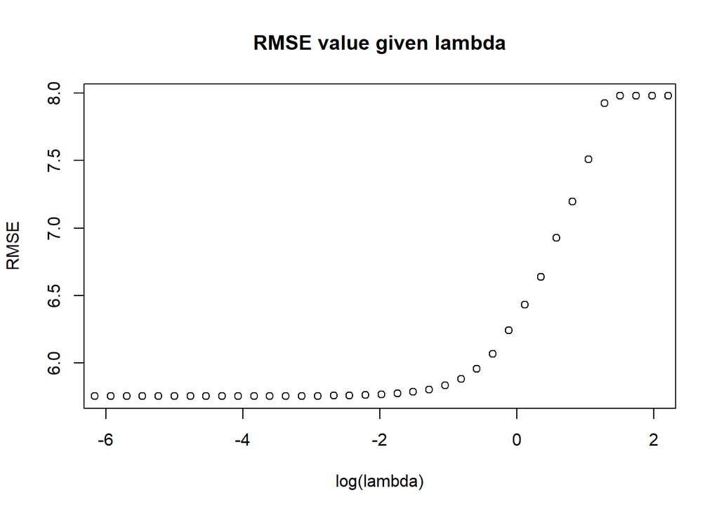

```r
# specifying 10-fold cross-validation as training method
cross_train <- trainControl(method="cv", number = 10,
                            savePredictions = "all")


# create vector for potential lambda values
vector_lambda <- 10^seq(5, -5, length = 100)


# build LASSO model using training data and cross-validation
model_lasso <- train(Bmi ~ ., data = obese_train,
                     preProcess = c("center", "scale"),
                     method = "glmnet",
                     tuneGrid = expand.grid(alpha = 1, lambda = vector_lambda),
                     trControl = cross_train)


# visualize how the log(lambda) affects the RMSE
plot(log(model_lasso$results$lambda), model_lasso$results$RMSE,
     xlab = "log(lambda)",
     ylab = "RMSE",
     main = "RMSE value given lambda",
     xlim = c(-6,2))
```

```r
# find best lambda value
best_lambda <- model_lasso$bestTune$lambda
log(best_lambda)
```

```
[1] -3.837642
```

The LASSO regression method did only shrink the coefficients of *CALCAlways* to zero. Thus, should we build a model on this information, nearly every variable would be included into the best subset selection. However the goal of finding the best model is to find a model that most accurately predicts the outcome variable and also be parsimonious.

Fortunately, with use of the variable importance function, we can see what variables show to have the greatest influence considering Bmi.

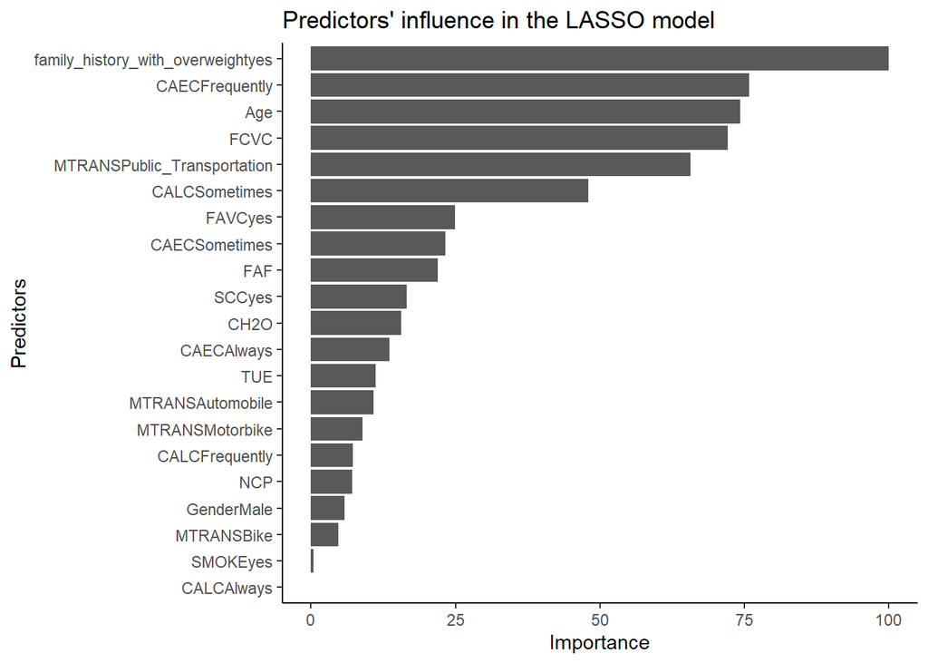

```r
# visualize the most important predictors
ggplot(varImp(model_lasso)) + labs(x = "Predictors", y = "Importance", title = "Predictors' influence in the LASSO model") + theme_classic()
```

## 5.4 Dummy Coding

For our models we explicitly need some of the categories of certain categorical variables. For example, from the categorical variable *MTRANS* we only need Public_Transportation. Thus we will need some dummy variables.

For this we can use dummy_cols() function from the “fastDunmmies” package. After dummy-coding, we can finalize our models and start comparing which is the best!

## 5.5 Model Comparison

At this point we have 4 possible best models.  
The **first** model is contains all variables (17 variables)  
The **second** model comes from forward stepwise selection (10 variables)  
The **third** model comes from backward stepwise selection (10 variables)  
Finally, the **fourth** model comes from LASSO regression (8 variables)

Considering the fact that the models regarding forward and backward selection are identical, we proceed to compare just **3** models.

```r
model_all <- lm(Bmi~., data=obese_dummy_train)

model_forward <- lm(Bmi ~ Age + family_history_with_overweight +
                      FAVC + FCVC + CAEC_Frequently + FAF +
                      CALC_Sometimes + MTRANS_Public_Transportation +
                      SCC + CH2O, data = obese_dummy_train)

model_lasso <- lm(Bmi ~ Age + family_history_with_overweight +
                      FAVC + FCVC + CAEC_Frequently + FAF +
                      CALC_Sometimes + MTRANS_Public_Transportation,
                      data = obese_dummy_train)
```

Let’s now compare the models with respect to the train data.  
- What models has the lowest RSS ?  
- What model has the lowest AIC ?  
- What model has the highest R-squared ?

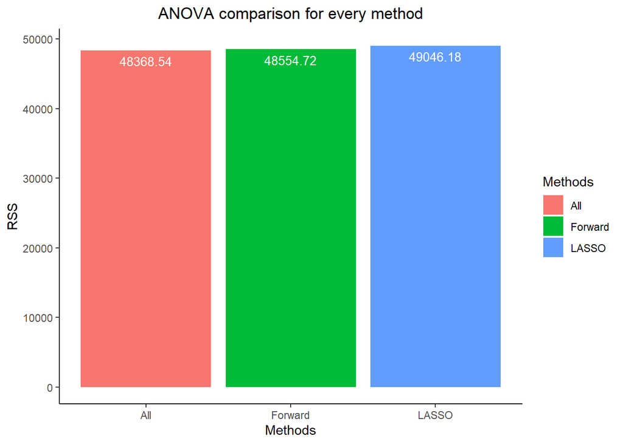

```r
# analysis of variance
anova_models <- anova(model_all, model_forward, model_lasso)
df_anova <- data.frame(Methods = c("All", "Forward", "LASSO"),
         RSS = c(48368.54, 48554.72, 49046.18))

# plot the ANOVA
ggplot(df_anova, aes(x=Methods, y=RSS, fill= Methods)) +
  geom_bar(stat="identity") +
  geom_text(aes(label=RSS), color="white", vjust = 1.6, size = 3.5) +
  theme_classic() + ggtitle("ANOVA comparison for every method") +
  theme(plot.title = element_text(hjust = 0.5))
```

When interpreting the output of the figure above, it shows that the full model has the lowest RSS. This means that the full model fits the training data better than the other models since it has the lowest deviations from the data points. Accordingly, we should go with the full model.

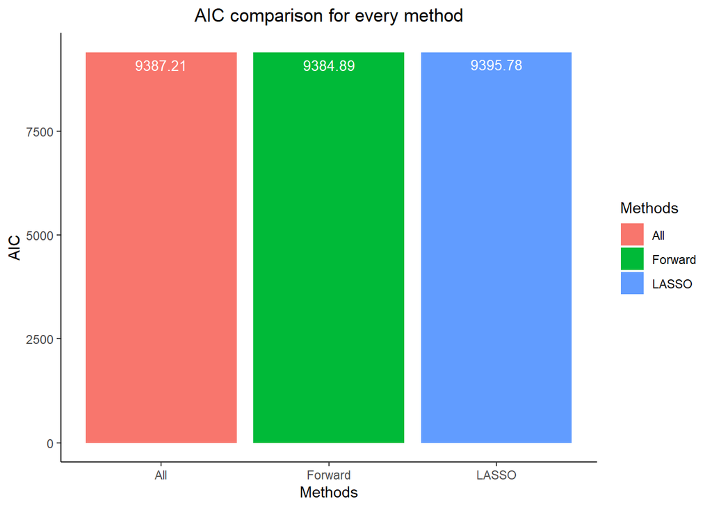

```r
# AIC criteria
AIC_all <- round(AIC(model_all),2)
AIC_forward <- round(AIC(model_forward),2)
AIC_lasso <- round(AIC(model_lasso),2)

df_aic <- data.frame(Methods = c("All", "Forward", "LASSO"),
                     AIC = c(AIC_all, AIC_forward, AIC_lasso))

# plot the AIC comparison
ggplot(df_aic, aes(x=Methods, y=AIC, fill = Methods)) +
  geom_bar(stat="identity") +
  geom_text(aes(label=AIC), color="white", vjust = 1.6, size = 3.5) +
  theme_classic() + ggtitle("AIC comparison for every method") +
  theme(plot.title = element_text(hjust = 0.5))
```

While the differences are small, when comparing the values of the AIC, the forward model has the lowest value. This is remarkable since the AIC punishes for adding variables to a model, one would expect that the LASSO model would come out best. However, according to the AIC, we should go with the forward model.

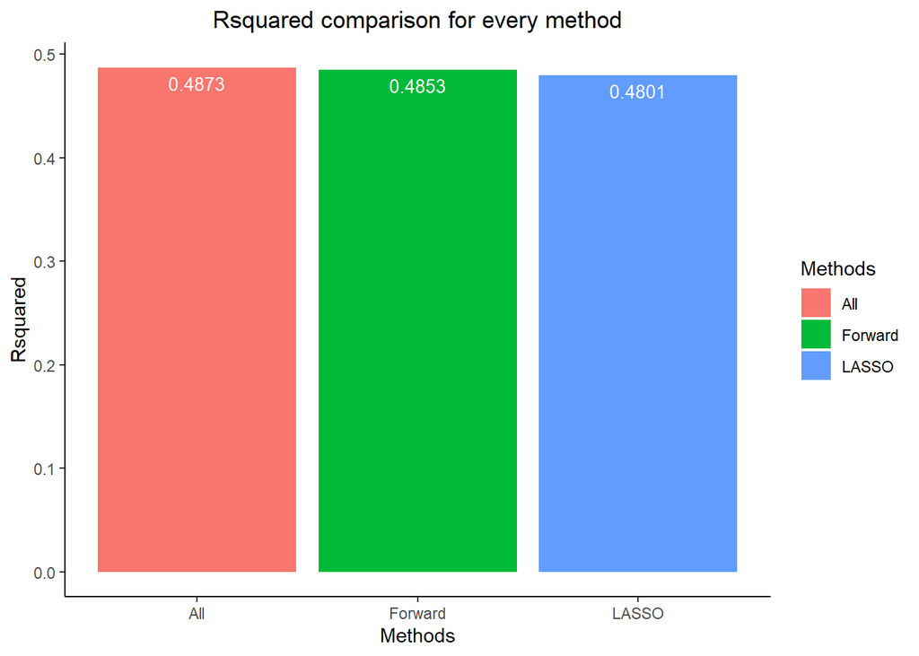

```r
# Explained variance (r-squared)
r_all <- round(summary(model_all)$r.squared,4)
r_forward <- round(summary(model_forward)$r.squared,4)
r_lasso <- round(summary(model_lasso)$r.squared,4)

# making a dataframe
df_r2 <- data.frame(Methods = c("All", "Forward", "LASSO"),
                    Rsquared = c(r_all, r_forward, r_lasso))

# plotting the comparison of Rsquared
ggplot(df_r2, aes(x=Methods, y=Rsquared, fill= Methods)) +
  geom_bar(stat="identity") +
  geom_text(aes(label=Rsquared), color="white", vjust = 1.6, size = 3.5) +
  theme_classic() + ggtitle("Rsquared comparison for every method") +
  theme(plot.title = element_text(hjust = 0.5))
```

When comparing the R-squared values of the models, the full model has the highest value for R-squared. This means that the full model explains the most variance of Bmi compared to the other models. Thus, according to the value of R-squared, we should go with the full model.

Let’s now compare the models with respect to the test data.  
- Which model does the best in predicting Bmi with new data?

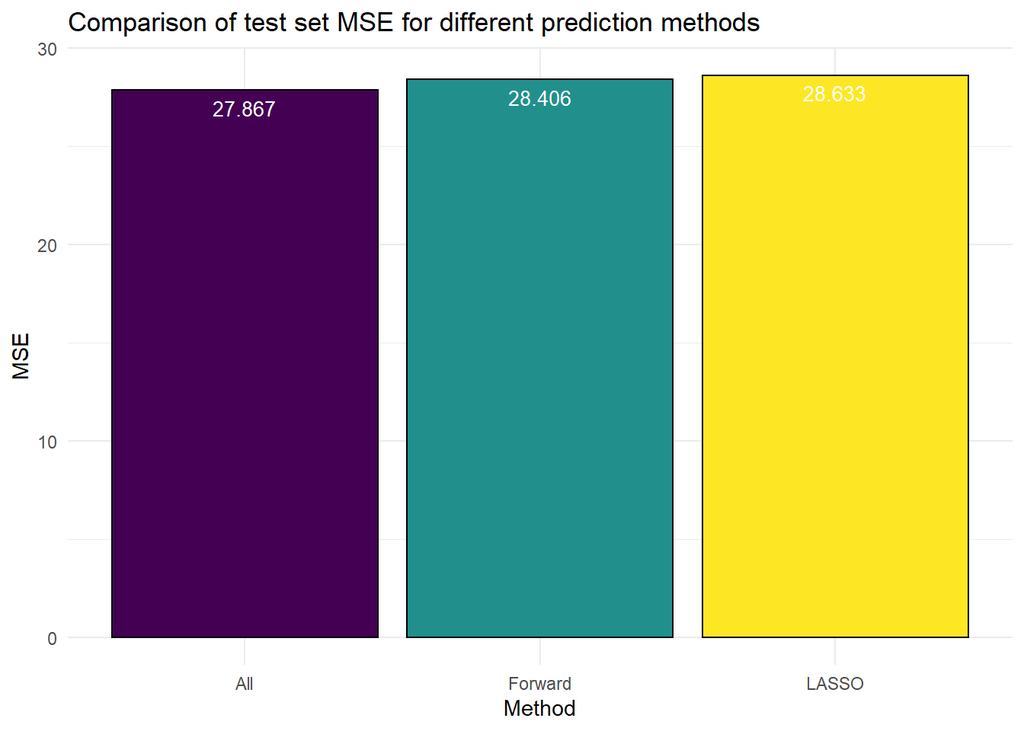

```r
# make the predictions for all models
predictions_model_all <- predict(model_all, newdata = obese_dummy_test)
predictions_model_forward <- predict(model_forward, newdata = obese_dummy_test)
predictions_model_lasso <- predict(model_lasso, newdata = obese_dummy_test)


# calculating RMSE's
mse <- function(y_true, y_pred) {
  mean((y_true - y_pred)^2)
}

mse_pred <- c(
  mse(obese_dummy_test$Bmi, predictions_model_all),
  mse(obese_dummy_test$Bmi, predictions_model_forward),
  mse(obese_dummy_test$Bmi, predictions_model_lasso))

# calculating R-squared
rsquareds <- c(
  R2(predictions_model_all,obese_dummy_test$Bmi),
  R2(predictions_model_forward,obese_dummy_test$Bmi),
  R2(predictions_model_lasso,obese_dummy_test$Bmi))

# plotting RMSE - comparison
tibble(Method = as_factor(c("All", "Forward", "LASSO")), MSE = round(mse_pred,3)) %>%
  ggplot(aes(x = Method, y = MSE, fill = Method)) +
  geom_bar(stat = "identity", col = "black") +
  geom_text(aes(label=MSE), color="white", vjust = 1.6, size = 3.5)+
  theme_minimal() +
  theme(legend.position = "none") +
  labs(title = "Comparison of test set MSE for different prediction methods") +
  scale_fill_viridis_d() # different colour scale
```

When comparing the MSE’s of the test data concerning model performance, the full model has the lowest value for MSE. This means that when given new data, the predictions for BMI of the full model come closest to the real observations of BMI. Thus, given the MSE value in the test data, we should again go for the full model.

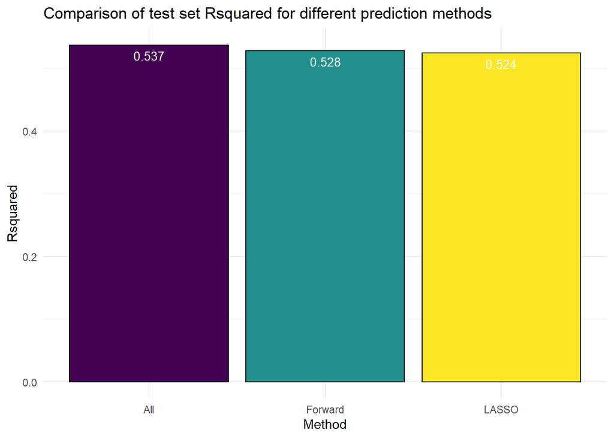

```r
# plotting R-squared - comparison
tibble(Method = as_factor(c("All", "Forward", "LASSO")), Rsquared = round(rsquareds,3)) %>%
  ggplot(aes(x = Method, y = Rsquared, fill = Method)) +
  geom_bar(stat = "identity", col = "black") +
  geom_text(aes(label=Rsquared), color="white", vjust = 1.6, size = 3.5) +
  theme_minimal() +
  theme(legend.position = "none") +
  labs(title = "Comparison of test set Rsquared for different prediction methods") +
  scale_fill_viridis_d() # different colour scale
```

When comparing the R-squared values in the test data, the differences are again small. However, the full model shows the highest value of R-squared compared to the other models / methods. Concluding, in every comparison, either in the training or test data, the full model comes out as the best model.

This conclusion is inevitable but also strange. Normally, a model containing all variables leads to problems such as overfitting, high MSE’s, high collinearity, bad predictions when dealing with new data, etc. Since this is *not* the case for this data set, we can only conclude that nearly all variables in this data set are meaningful when predicting BMI.

**Note**: Only when comparing the AIC within the train data, the forward model comes out better than the full model.Furthermore, since we’re not interested in a model that contains all variables, we will further elaborate on our second best model: *forward stepwise selection*

# 6 Model Evaluation

Now let’s elaborate on our “best” model, given by **Forward stepwise selection**.

```r
# summary model forward
summary(model_forward)
```

```
Call:
lm(formula = Bmi ~ Age + family_history_with_overweight + FAVC +
    FCVC + CAEC_Frequently + FAF + CALC_Sometimes + MTRANS_Public_Transportation +
    SCC + CH2O, data = obese_dummy_train)

Residuals:
     Min       1Q   Median       3Q      Max
-17.8955  -4.1536   0.4037   3.8279  23.1060

Coefficients:
                                  Estimate Std. Error t value Pr(>|t|)
(Intercept)                         1.6503     1.3207   1.250 0.211664
Age                                 0.3090     0.0298  10.368  < 2e-16 ***
family_history_with_overweightyes   6.6524     0.4246  15.666  < 2e-16 ***
FAVCyes                             1.8598     0.4993   3.725 0.000203 ***
FCVC                                3.5992     0.2839  12.677  < 2e-16 ***
CAEC_Frequently                    -6.9934     0.4920 -14.215  < 2e-16 ***
FAF                                -0.6842     0.1861  -3.677 0.000244 ***
CALC_Sometimes                      2.5526     0.3291   7.758 1.61e-14 ***
MTRANS_Public_Transportation        4.3376     0.4274  10.149  < 2e-16 ***
SCCyes                             -2.1550     0.7348  -2.933 0.003413 **
CH2O                                0.6583     0.2532   2.600 0.009423 **
---
Signif. codes:  0 '***' 0.001 '**' 0.01 '*' 0.05 '.' 0.1 ' ' 1

Residual standard error: 5.751 on 1468 degrees of freedom
Multiple R-squared:  0.4853,    Adjusted R-squared:  0.4818
F-statistic: 138.4 on 10 and 1468 DF,  p-value: < 2.2e-16
```

All predictors in the forward model are highly significant. Furthermore, the forward model explains 48,5% of the variance in BMI, which is also significant, p < 2.2e-16.

## 6.1 VIF

To make sure there is no multicollinearity in the forward model, we must calculate the Variance Inflation Factor (VIF). The VIF calculates the strength of correlation between the variables in the model. When the VIF exceeds a value of **5** for certain variables, the coefficient estimates and p-values for the forward model will become unreliable.

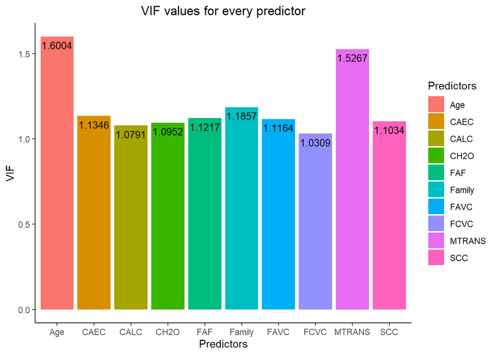

```r
# visualize the vif values
vif_model <- vif(model_forward)

df_vif <- data.frame(Predictors = c("Age", "Family", "FAVC",
                                    "FCVC", "CAEC", "FAF",
                                    "CALC", "MTRANS", "SCC", "CH2O"),
                            VIF = c(1.6004, 1.1857, 1.1164, 1.0309,
                                   1.1346, 1.1217, 1.0791, 1.5267,
                                   1.1034, 1.0952))

ggplot(df_vif, aes(x=Predictors, y=VIF, fill = Predictors)) +
  geom_bar(stat="identity") +
  geom_text(aes(label=VIF), color="black", vjust = 1.6, size = 3.5) +
  theme_classic() + ggtitle("VIF values for every predictor") +
  theme(plot.title = element_text(hjust = 0.5))
```

The forward model has no problem with multicollinearity for it’s predicting variables, as visualized in the figure above.

## 6.2 Test-Performance

But then, what about outside training data performance?  
Specifically, how well does the forward model deal with new information?

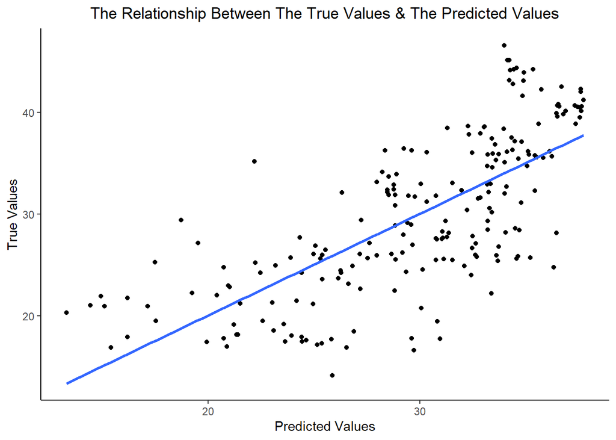

```r
# store predictions of the foward model given new data
pred_bmi <- predict(model_forward, newdata = obese_dummy_test)

# make a dataframe for the true values in test and the predicted values
true_predicted <- data.frame(True_value = obese_dummy_test$Bmi,
                             Pred_value = pred_bmi)
# plot this relationship
ggplot(true_predicted, aes(x=Pred_value, y=True_value)) +
  geom_point() + geom_smooth(method=lm, se=FALSE) +
  labs(x = "Predicted Values", y="True Values") +
  ggtitle("The Relationship Between The True Values & The Predicted Values") +
  theme_classic() +
  theme(plot.title = element_text(hjust = 0.5))
```

The correlation between the actual values in the test data and the predicted values from the forward model is nearly 73%. This does not resound the model accuracy perfectly, but this correlation rather represents the similarity of the movement.

```r
# now let's look at the correlations between those values, representing the accuracy
cor(true_predicted)
```

```
##            True_value Pred_value
## True_value  1.0000000  0.7267121
## Pred_value  0.7267121  1.0000000
```

Finally, let’s look at the Min_Max accuracy. A perfect model would have a Min_Max accuracy of 1.0, the further away from 1.0 the further away the predicted values are from the true values.

```r
min_max_performance <- mean(apply(true_predicted, 1, min) / apply(true_predicted, 1, max))
round(min_max_performance, 2)
```

```
[1] 0.86
```

The value for Min_Max accuracy is 0.86, thus the accuracy in which the forward model predicts the BMI of new cases is ~86%.

# 7 Checking Assumptions

To be able to create a linear model, several assumptions have to met. We will now check for outliers, normality.

The diagRegressionPlots() function makes a few plots automatically which are useful in determining whether linear regression is working on a data set. This is part of the “HannayIntroStats” package (https://github.com/khannay/HannayIntroStats).

```r
diagRegressionPlots <- function(regression.obj, cex=1)
{
  par(mfrow=c(2,2))
  #Grab the names of the two variables
  var.names=attr(regression.obj$model, "names")

  x=regression.obj$model[,2]
  y=regression.obj$model[,1]


  qqnorm(as.vector(regression.obj$residuals), main="Normality check QQ Plot", cex=cex)
  qqline(as.vector(regression.obj$residuals), col='red')
  plot(x,regression.obj$residuals, main='Residual Plot', ylab='Residuals', xlab=var.names[2], cex=cex)
  hist(regression.obj$residuals, main='Histogram for the Residuals', xlab='Residual Value', col='lightblue')

  #plot the regression
  title=paste(c('Model Fit R^2=', round(summary(regression.obj)$r.squared,2)), collapse=" ")
  plot(x,y, main=title, xlab=var.names[2], ylab=var.names[1], cex=cex)
  abline(regression.obj, col='red')
  par(mfrow=c(1,1))
}
```

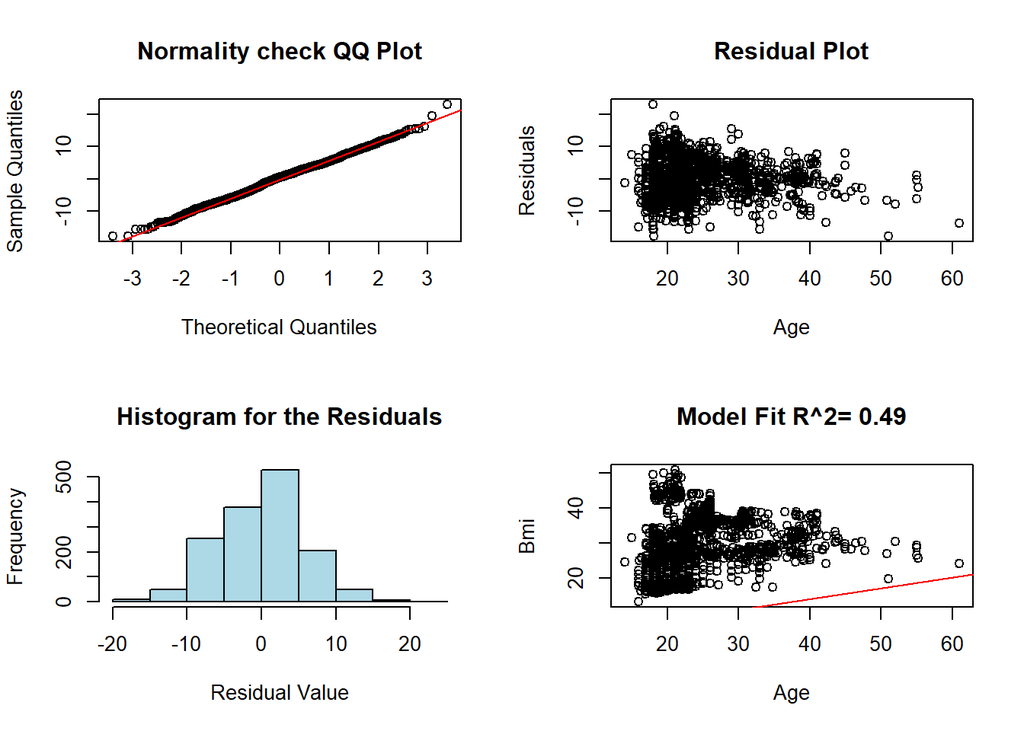

```r
# This call of diagRegressionPlots() should produce four plots for the assumptions checking of a linear model
diagRegressionPlots(model_forward)
```

## 7.1 Checking for linearity

For the linearity assumption of linear regression, the relationship between X and the mean of Y should be linear. It is tested with the residuals vs. fitted plot. If the residuals are evenly distributed along a horizontal line with no apparent patterns (the red line is approximately horizontal at zero), that is a good indication of a linear relationship.

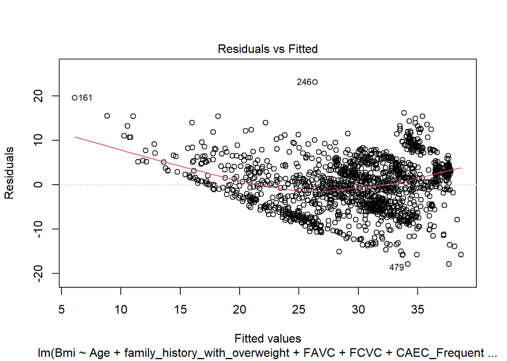

```r
plot(model_forward, 1)
```

*Interpretation:*

In the Residuals vs. Fitted plot we see a slight curve in residuals. Most of the residuals are equally spread around the horizontal line without any distinct patterns. There seems to be a deviation from the rest of the residuals for lower fitter values, indicating possible outliers. Even though there’s a deviation for lower fitted values, there are no extreme deviations. Hence the linearity assumption is not violated.

## 7.2 Checking whether the predictor matrix is full rank

The predictor matrix is full rank when there are more rows than columns in a dataset.

```r
dim(obese_dummy_train)
```

```
## [1] 1479   15
```

*Interpretation:*

The dataset contains 1479 rows and 15 columns. This means the assumption of the predictor matrix to be full rank is satisfied. Moreover, the predictors are not linear combinations of other predictors.

## 7.3 Checking for homoscedasticity

For the homoscedasticity assumption, the residual variance should be the same for every value of X in the model. Non-constant error variance means that there is heteroscedasticity. The scale-location plot is used to check the homoscedasticity of residuals (equal variance of residuals). The assumption is met if the residuals are randomly scattered and show a horizontal line with equal (random) scatter points.

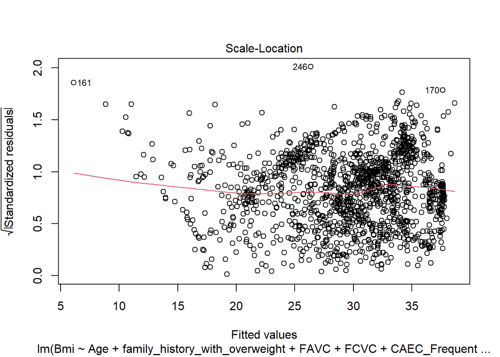

```r
plot(model_forward, 3)
```

The residuals are random and reasonably evenly distributed. The red line is relatively flat, which corresponds to constant error variance. Since there is no clear trend in the current data, the assumption is met.

## 7.4 Checking if the errors are normally distributed

The normality assumption is important for prediction because prediction intervals require normally distributed errors. The normal Q-Q plot is used to check if the residuals are normally distributed for the normality assumption. If the majority of the residuals follow the straight dotted line, the assumption is met. Besides the normal Q-Q plot, we also take a look at the histogram of the model to check this assumption.

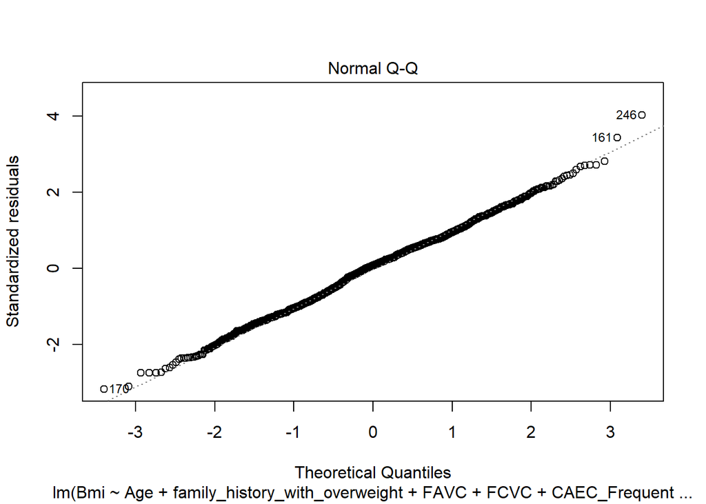

```r
plot(model_forward, 2)
```

*Interpretation:*

After estimating the normal distribution from the regression model, a normal Q-Q plot was derived. Both the lower and upper ends deviate slightly from the dotted line.

To better visualize the distribution of the errors, we also analyze the histogram of the model.

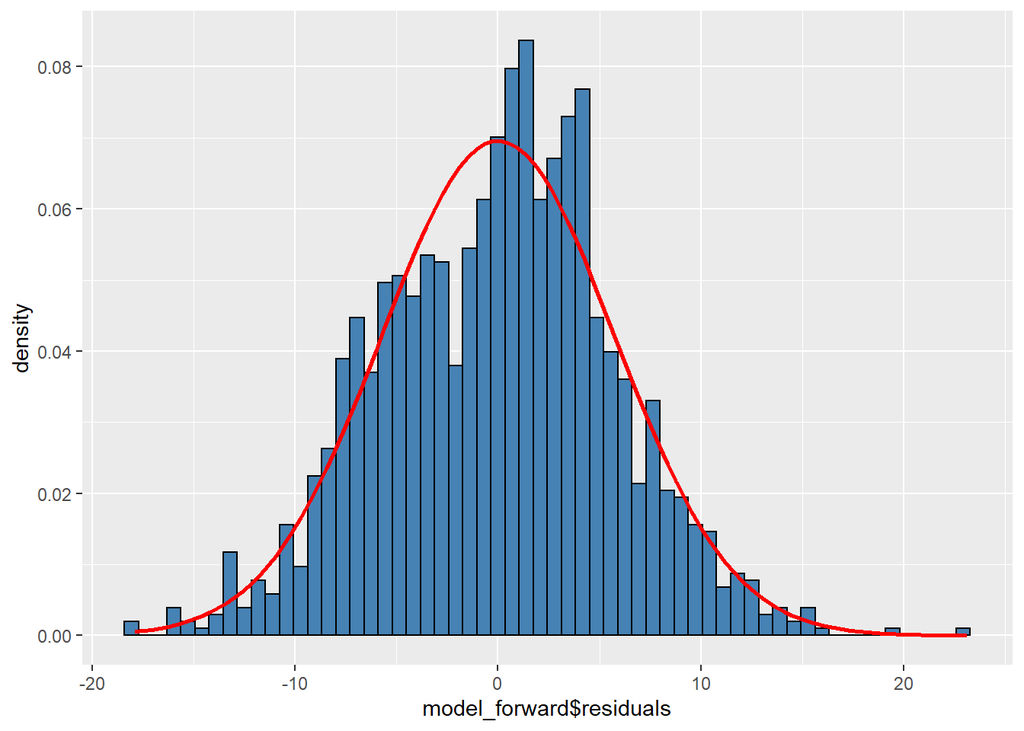

```r
ggplot(data = obese_train, aes(x = model_forward$residuals)) +
  geom_histogram(aes(y= ..density..), col = 'black', fill = 'steelblue', bins = 60) +
  stat_function(fun = dnorm,
                args = list(mean = mean(model_forward$residuals),
                                        sd = sd(model_forward$residuals)),
                col = "red",
                size = 1)
```

*Interpretation:*

In the histogram we can observe that there is a very slight left skew in our data. However, the skewness is close to zero, and the distribution shape of our data mostly overlaps with the red reference line (which represents for perfect normal distribution). The distributions of the residuals seem to be moderate in breadth.

Based on the normal Q-Q plot and the histogram, we can say that the normality assumption is met.

## 7.5 Checking influential observations and outliers

Influential observations are observations in the dataset that, when removed, dramatically change the coefficient estimates of the regression model. Therefore, we will look at the data and see if we have any influential observations.

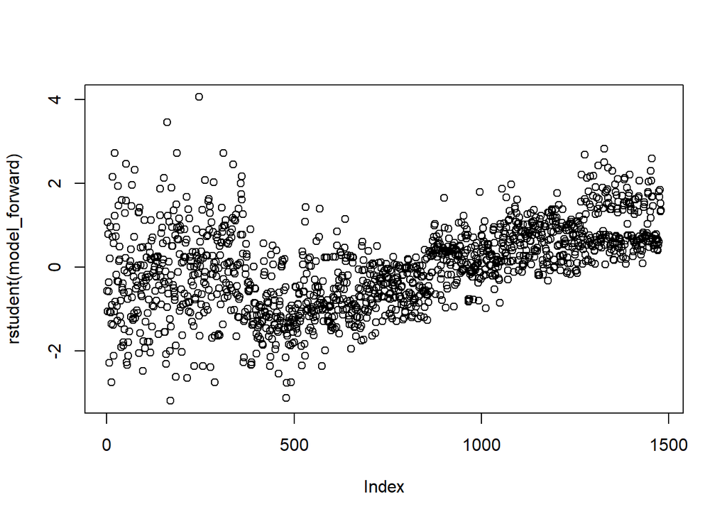

```r
plot(rstudent(model_forward))
```

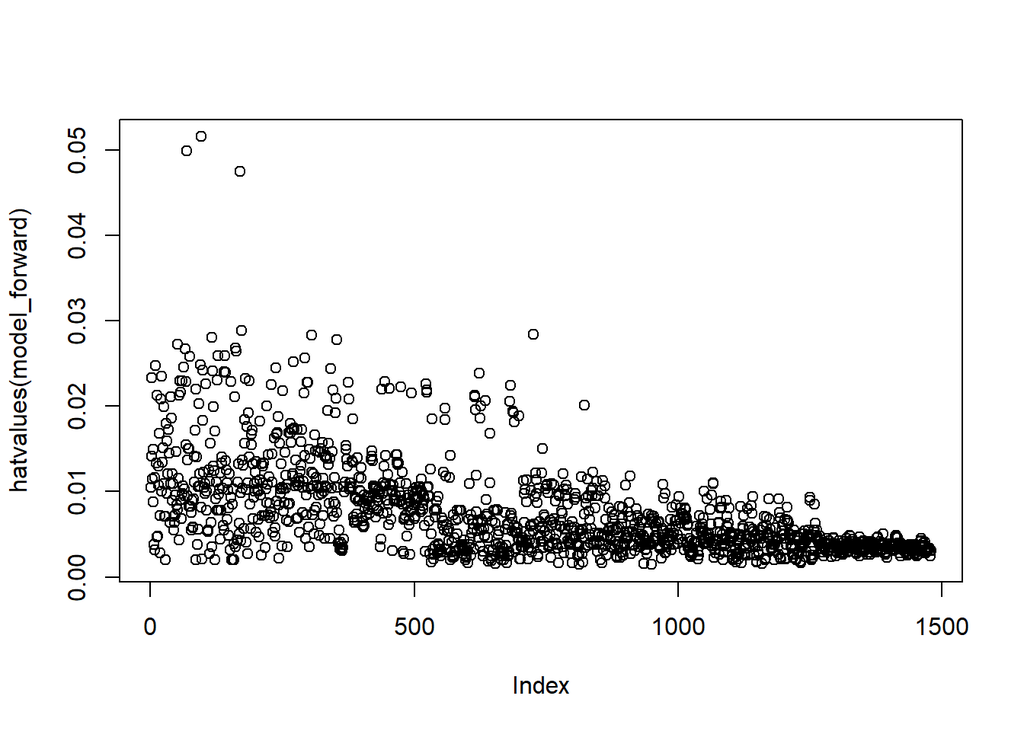

```r
plot(hatvalues(model_forward))
```

```r
(maxDs1 <- sort(rstudent(model_forward)) %>% names() %>% tail(2) %>% as.numeric())
```

```
## [1] 161 246
```

```r
(maxDs2 <- sort(hatvalues(model_forward)) %>% names() %>% tail(3) %>% as.numeric())
```

```
## [1] 170  69  96
```

*Interpretation:*

From the RStudent plot, it can be deducted that there are no observations that clearly stand out from the crowd. However, according to the rule of thumb, points above 3.0 level are flagged as possible outliers. The corresponding observations are 161 and 246 which means that 2 possible outliers are detected. However, as the variation in the data is big, these observations are not seen as “standing out from the crowd”. There is no clear distinction between these two observations that have a value >3 and the other observations. Due to that, these cases are not excluded.

For the leverage plot (hatvalues), there are three points that are noticeably different from the rest, which means they could be high-leverage points. By sorting the data with the three highest hatvalues, observations 170, 69, and 96 are obtained.

To see whether removing the three highest hatvalue observations has a positive influence on the leverage plot, the plot with and without these three observations are compared.

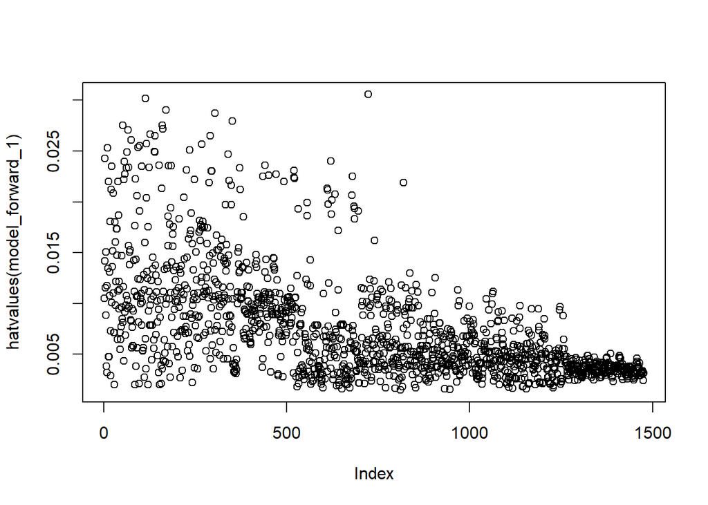

```r
# Remove the possible high-leverage observations 170, 69, and 96.
obese_dummy_train_1 <- obese_dummy_train[-maxDs2, ]

model_forward_1 <- lm(Bmi ~ Age + family_history_with_overweight +
                      FAVC + FCVC + CAEC_Frequently + FAF +
                      CALC_Sometimes + MTRANS_Public_Transportation +
                      SCC + CH2O, data = obese_dummy_train_1)

plot(hatvalues(model_forward_1))
```

*Interpretation:*

```r
r1 <- summary(model_forward)$r.squared
r2 <- summary(model_forward_1)$r.squared

aic1 <- AIC(model_forward)
aic2 <- AIC(model_forward_1)

mse1 <- MSE(y_pred = predict(model_forward), y_true = obese_dummy_train$Bmi)
mse2 <- MSE(y_pred = predict(model_forward_1), y_true = obese_dummy_train_1$Bmi)

# Combining the outputs of R-Squared, AIC and MSE into a table for Model 1 and 2
rsquared_bind <- rbind(r1, r2)
aic_bind <- rbind(aic1, aic2)
mse_bind <- rbind(mse1, mse2)
table_all <- cbind.data.frame(rsquared_bind, aic_bind, mse_bind)
colnames(table_all) = c("R-Squared", "AIC", "MSE")
rownames(table_all) = c("Model 1", "Model 2")
table_all
```

```
##         R-Squared      AIC      MSE
## Model 1 0.4852923 9384.890 32.82943
## Model 2 0.4904765 9351.779 32.51679
```

After estimating both models, the R-squared for Model 1 is 0.4852923, whereas the R-squared for the Model 2 is 0.4904765 This suggests that deleting these three observations leads to a slightly higher amount of explained variation.

The AIC of Model 1 is higher than the AIC of Model 2, with the values 9384.890 vs. 9351.779, respectively.

The comparisons suggest that Model 2, where three observations are deleted, makes a better model since the R-squared improves and the AIC and MSE decrease. Therefore, we will use Model 2.

To confirm these results, we apply measures of influence to account for both extremities for the x and the y axis.

### 7.5.1 Cook’s Distance

There are two measures of influence. The first method used is a global measure of influence identified by the Cook’s Distance.

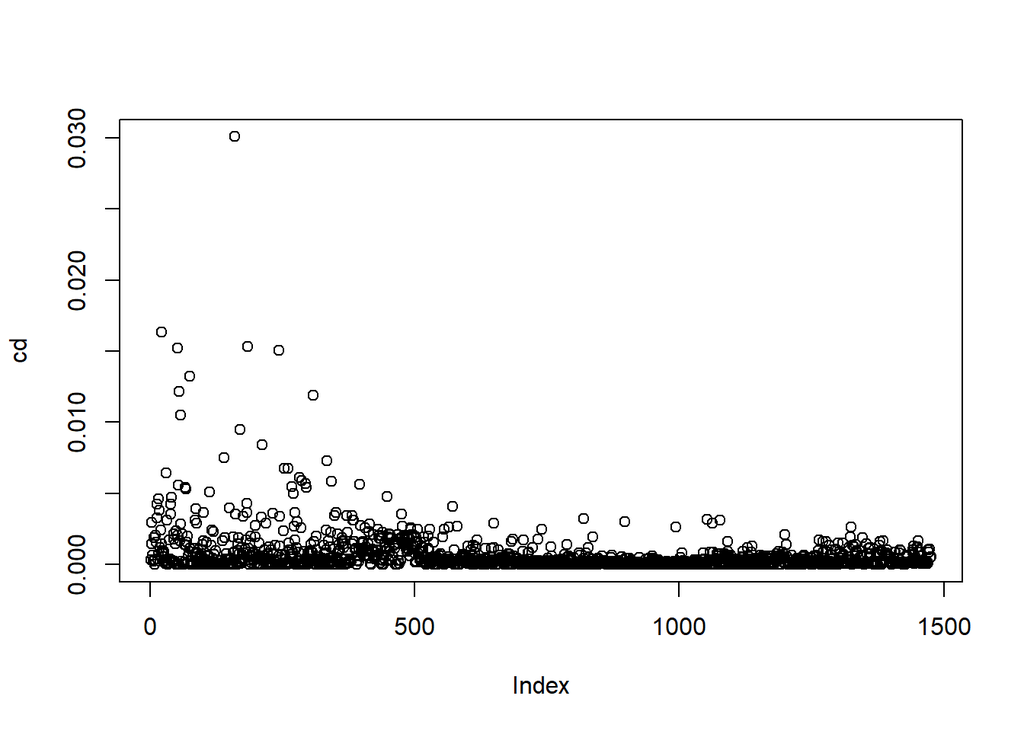

```r
cd <- cooks.distance(model_forward_1)
plot(cd)
```

```r
(maxDs3 <- which.max(cd))
```

```
## 161
## 159
```

*Interpretation:*

In the Cook’s Distance plot, one point is noticeably different from the rest, observation number 159. This observation negatively affects the regression model, which means it is a influential outlier.

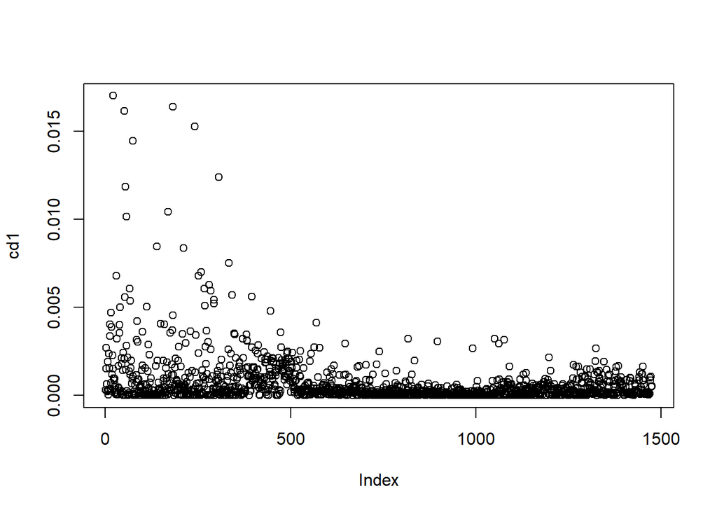

```r
# Remove the possible high-leverage observations 159.
obese_dummy_train_2 <- obese_dummy_train_1[-maxDs3, ]

model_forward_2 <- lm(Bmi ~ Age + family_history_with_overweight +
                      FAVC + FCVC + CAEC_Frequently + FAF +
                      CALC_Sometimes + MTRANS_Public_Transportation +
                      SCC + CH2O, data = obese_dummy_train_2)

cd1 <- cooks.distance(model_forward_2)
plot(cd1)
```

*Interpretation:*

After deleting observation 159, we analyzed the new Cook’s Distance plot. Now there are no data points that really distinguish themselves from the other data points.

To see whether removing this observation improved the model fit, we compare the model with and without this observation.

```r
r3 <- summary(model_forward_2)$r.squared
aic3 <- AIC(model_forward_2)
mse3 <- MSE(y_pred = predict(model_forward_2), y_true = obese_dummy_train_2$Bmi)

# Combining the outputs of R-Squared, AIC and MSE into a table for Model 1, 2, and 3
rsquared_bind <- rbind(r1, r2, r3)
aic_bind <- rbind(aic1, aic2, aic3)
mse_bind <- rbind(mse1, mse2, mse3)
table_all_1 <- cbind.data.frame(rsquared_bind, aic_bind, mse_bind)
colnames(table_all_1) = c("R-Squared", "AIC", "MSE")
rownames(table_all_1) = c("Model 1", "Model 2", "Model 3")
table_all_1
```

```
##         R-Squared      AIC      MSE
## Model 1 0.4852923 9384.890 32.82943
## Model 2 0.4904765 9351.779 32.51679
## Model 3 0.4944516 9334.646 32.27928
```

*Interpretation:*

After estimating the three models, the R-squared for Model 3 is the highest R-squared with 0.4944516, compared to 0.4852923 for Model 1 and 0.4904765 for Model 2. This suggests that deleting the observation leads to the best model with the most explained variation.

The AIC of Model 3 is the lowest with 9334.646, compared to 9384.890 for Model 1 and 9351.779 for Model 2.

Finally, the MSE of Model 3 is the lowest with 32.27928, compared to 32.82943 for Model 1 and 32.51679 for Model 2.

The comparisons suggest that the model again improves when deleting the observation, as the R-squared increases and both the AIC and MSE decrease. Therefore, we delete this observation from the dataset as well.

### 7.5.2 DFBETAS

The second method to measure influence is a coefficient-specific measure of the influence analyzed with DFBETAS.

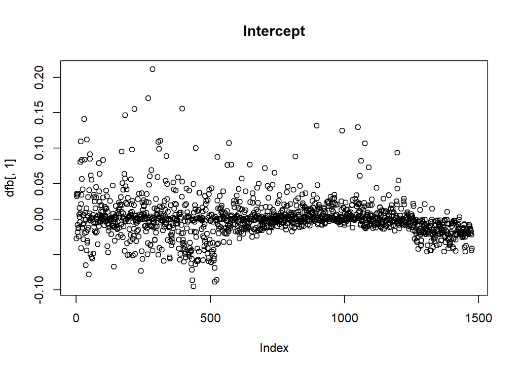

```r
dfb <- dfbetas(model_forward_2)
dfb_intercept <- plot(dfb[ , 1], main = "Intercept")
```

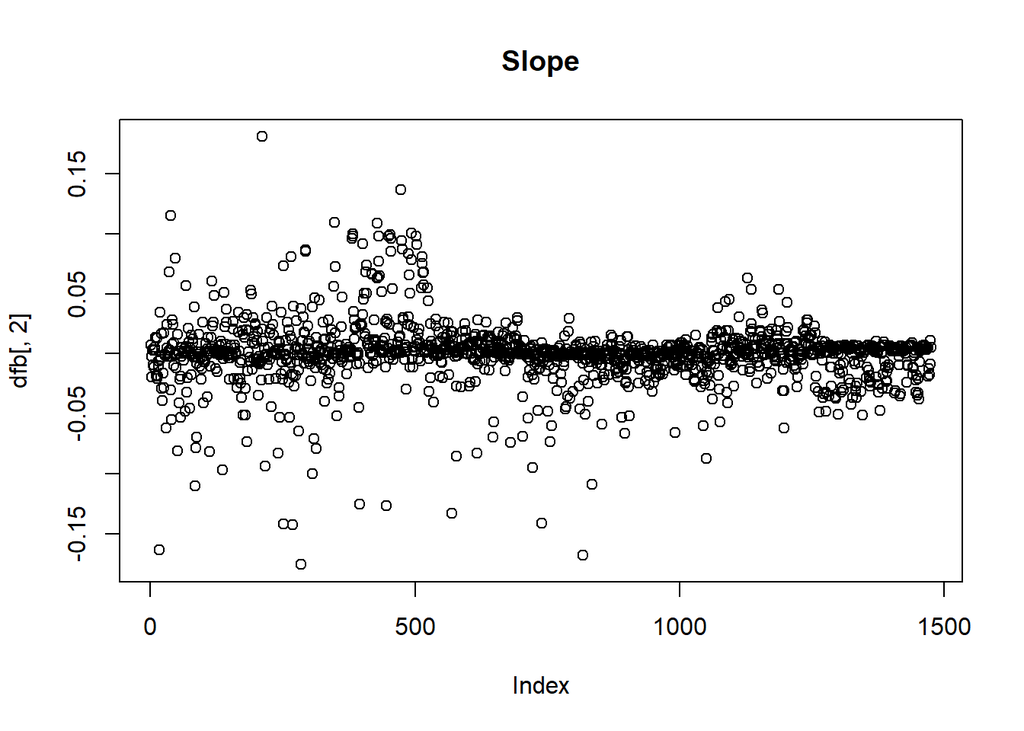

```r
dfb_slope <- plot(dfb[ , 2], main = "Slope")
```

*Interpretation:*

For the DFBETAS Intercept plot, there are no points that are “standing out from the crowd.” Besides, the estimation value of the intercept does not apply to the current study. Therefore, we do not remove any of these observations.

There are also no data points distinguishable from the rest for the slope plot. In conclusion, looking at the DFbetas plots, no observation needs to be removed.

# 8 Answering Research Question

The research question for this assignment was ‘What predictors show the greatest influence regarding a person’s BMI?’. Algorithms were used like lasso regression and forward and backward selection to create several models using the predictors from the training data. These models were separately tested on fit to the test data. The best fitting model was a model using all variables, having the best ANOVA results, lowest MSE and highest Rsquared. As we do not want to use all variables the second best fitting model was used (which had the lowest AIC), with a difference in degrees of freedom of 7. This model was created by forward selection and is identical to the backwards selection model. The final model was checked on assumptions and used to create visualizations of the data and model.

# 9 Discussion & Limitations

The obesity dataset of Palechor & Monatas (2019) gave several models after use of algorithms to predict a person’s BMI. Because the best predicting model used all variables a less complex model was used to filter out the best predictors. Best predicting variables were picked by use of a forward selection algorithm.

The best fitting model was not used as it made use of all possible variables as our goal was to find the best predictors, using the elaborative model would not fit. However, the first model is still best to predict a person’s BMI according to the runnen tests, so should be used to predict the BMI.

Furthermore, the individual-level data is limited due to this incorrect artificially created data. The dummy variables representing categorical data had floating digits in the artificially created data, which is not possible for dummy variables. Nevertheless, the synthetic data is still representative on a macro-level, but not on an individual level. However the artificial data is incorrect on microlevel, the data balances the representation of categories. This is very important to prevent training alortigms to only predict the well represented categories correctly. Therefore the use of the dataset containing artificial data is justified.

A limitation of our research is that the data was collected in Latin American countries, it does not represent the average population. The found predictors in this research are the biggest predictors for BMI in Latin American countries. Further research needs to be done to prove the predicting value of these variables in different cultures.

# 10 Task Division

**William Schaafsma** (1705318)  
- 1. Introduction and Research Question  
- 2. Loading Packages, Dataset & Set seed  
- 3.1 Preprocessing (Data Manipulation), 3.2 Splitting The Data Into Train, Validation & Test,  
- 3.3 Explaining The Variables.  
- 5. Model Training  
- 6. Model Evaluation

**Hau Nguyen** (6510841)  
- 2. Loading Packages  
- 4. Exploratory Data Analysis  
- 7. Checking Assumptions

**Qingyu Meng** (7099703)  
- 2. Loading Packages  
- 3.1 Preprocessing (Data Manipulation), 3.2 Splitting The Data Into Train, Validation & Test  
- 4. Exploratory Data Analysis  
- 7. Checking Assumptions

**Bénine Karssen** (6475582)  
- 3.4 Getting To Know The Data  
- 8. Answering Research Question  
- 9. Discussion & Limitations